# Agricultural Drilldown on Kiva Loans Using Reticulate

I’ve already gained some familiarity with this data from building a Shiny app for mapping it, but I want to take this opportunity to also brush up my Python and use reticulate to smoothly integrate with R.

For this specific notebook, I’m going to take a closer look at agricultural loans and see what we can learn about them. I already did some initial data cleaning and manipulation in R for the map, so I’m going to reuse that element.

```r
library(reticulate)
library(magrittr)
library(dplyr)
use_condaenv("py3")

knitr::knit_engines$set(python = reticulate::eng_python)

source("kiva_loan_cleaning.R")
```

After pulling in the data initially from my existing R script, now I’m calling it into python and converting it to a pandas df for continuing along.

```python
import pandas as pd
loanspd = pd.DataFrame(r.loans)
print(loanspd.head(n=5))
```

```
##        id  funded_amount  loan_amount             activity          sector  \
## 0  653051          300.0        300.0  Fruits & Vegetables            Food
## 1  653053          575.0        575.0             Rickshaw  Transportation
## 2  653068          150.0        150.0       Transportation  Transportation
## 3  653063          200.0        200.0           Embroidery            Arts
## 4  653084          400.0        400.0           Milk Sales            Food
##
##                                                  use country_code   country  \
## 0            To buy seasonal, fresh fruits to sell.            PK  Pakistan
## 1  to repair and maintain the auto rickshaw used ...           PK  Pakistan
## 2  To repair their old cycle-van and buy another ...           IN     India
## 3  to purchase an embroidery machine and a variet...           PK  Pakistan
## 4                           to purchase one buffalo.           PK  Pakistan
##
##          region currency    ...                   funded_time term_in_months  \
```

[output cut: 21 more lines]

Looks like what I’m expecting, great.

## By Country

```python
import numpy as np
loanspd['Agriculture'] =  np.where(loanspd['sector']=="Agriculture", True, False)
print(loanspd.head(n=5))
```

```
##        id  funded_amount  loan_amount             activity          sector  \
## 0  653051          300.0        300.0  Fruits & Vegetables            Food
## 1  653053          575.0        575.0             Rickshaw  Transportation
## 2  653068          150.0        150.0       Transportation  Transportation
## 3  653063          200.0        200.0           Embroidery            Arts
## 4  653084          400.0        400.0           Milk Sales            Food
##
##                                                  use country_code   country  \
## 0            To buy seasonal, fresh fruits to sell.            PK  Pakistan
## 1  to repair and maintain the auto rickshaw used ...           PK  Pakistan
## 2  To repair their old cycle-van and buy another ...           IN     India
## 3  to purchase an embroidery machine and a variet...           PK  Pakistan
## 4                           to purchase one buffalo.           PK  Pakistan
##
##          region currency     ...      term_in_months lender_count  \
```

[output cut: 21 more lines]

```python
agloan = loanspd[loanspd['Agriculture'] == True]
bycountry = agloan.groupby(['country', 'Agriculture'])
sumcountry = bycountry['usd_amt'].describe()
print(sumcountry.head(n=5))
```

```
##                          count          mean           std         min  \
## country    Agriculture
## Albania    True          719.0     13.316777      5.971812    3.809524
## Armenia    True         4630.0   1003.486229   1123.020850    0.052088
## Azerbaijan True         1148.0    853.353253    539.481150  191.232714
## Belize     True          125.0    456.602257    303.844502   75.082590
## Benin      True            2.0  25000.351012  35354.842654    0.702024
##
##                                  25%           50%           75%           max
## country    Agriculture
## Albania    True             7.857143     11.904763     18.571430     28.333335
## Armenia    True             3.021085    700.000000   2000.000000   3000.000000
## Azerbaijan True           603.118559    838.481899   1015.004404   9811.709236
## Belize     True           250.275300    312.844125    663.229545   1489.138035
## Benin      True         12500.526518  25000.351012  37500.175506  50000.000000
```

I discovered that I can’t make R handle a pandas summary object directly, so this summary work I did in python has to be done in R. Not a big deal, I’m sure I’ll figure out how to coerce a summary object sometime later!

### Table - Top 20 Countries

```r
ag_df <- py$agloan %>%
  group_by(country, Agriculture) %>%
  summarize(mean_loan = mean(usd_amt, na.rm = T)
            , median_loan = median(usd_amt, na.rm = T)
            , min_loan = min(usd_amt, na.rm = T)
            , max_loan = max(usd_amt, na.rm=T)
            , n())

ag_df <- ag_df %>%
  ungroup() %>%
  top_n(20, wt=median_loan)

knitr::kable(ag_df)
```

| country | Agriculture | mean_loan | median_loan | min_loan | max_loan | n() |
| --- | --- | --- | --- | --- | --- | --- |
| Armenia | TRUE | 1003.4862 | 700.0000 | 5.208770e-02 | 3000.000 | 4630 |
| Azerbaijan | TRUE | 853.3533 | 838.4819 | 1.912327e+02 | 9811.709 | 1148 |
| Benin | TRUE | 25000.3510 | 25000.3510 | 7.020237e-01 | 50000.000 | 2 |
| Brazil | TRUE | 15389.6393 | 15389.6393 | 7.792787e+02 | 30000.000 | 2 |
| Chile | TRUE | 49925.0000 | 49925.0000 | 4.992500e+04 | 49925.000 | 1 |
| Cote D’Ivoire | TRUE | 50000.0000 | 50000.0000 | 5.000000e+04 | 50000.000 | 1 |
| Ecuador | TRUE | 980.1651 | 850.0000 | 1.000000e+02 | 50000.000 | 5300 |
| El Salvador | TRUE | 667.7903 | 600.0000 | 1.000000e+02 | 3000.000 | 14009 |
| Iraq | TRUE | 2371.4286 | 2400.0000 | 1.500000e+03 | 3000.000 | 7 |
| Israel | TRUE | 1054.9420 | 1054.9420 | 4.885302e+02 | 1621.354 | 2 |
| Jordan | TRUE | 1797.3328 | 1658.4332 | 6.351446e+02 | 5045.871 | 173 |
| Kosovo | TRUE | 1845.7541 | 1718.2130 | 3.068238e+02 | 3405.744 | 440 |
| Palestine | TRUE | 1654.1012 | 1500.0000 | 1.486831e+02 | 4000.000 | 975 |
| Panama | TRUE | 1488.0137 | 1000.0000 | 2.000000e+02 | 6000.000 | 73 |
| Puerto Rico | TRUE | 7398.0769 | 8000.0000 | 3.000000e+03 | 10000.000 | 13 |
| Saint Vincent and the Grenadines | TRUE | 1162.0370 | 1162.0370 | 9.444444e+02 | 1379.630 | 2 |
| Somalia | TRUE | 750.0000 | 750.0000 | 3.000000e+02 | 1200.000 | 2 |
| The Democratic Republic of the Congo | TRUE | 921.5481 | 500.0000 | 5.000000e+01 | 9950.000 | 478 |
| Timor-Leste | TRUE | 805.1948 | 800.0000 | 3.000000e+02 | 1500.000 | 231 |
| United States | TRUE | 7441.8114 | 9900.0000 | 2.000000e+02 | 10000.000 | 403 |
| Zimbabwe | TRUE | 771.9852 | 500.0000 | 3.000000e+02 | 6100.000 | 1078 |

### Plot - Top 20 Countries

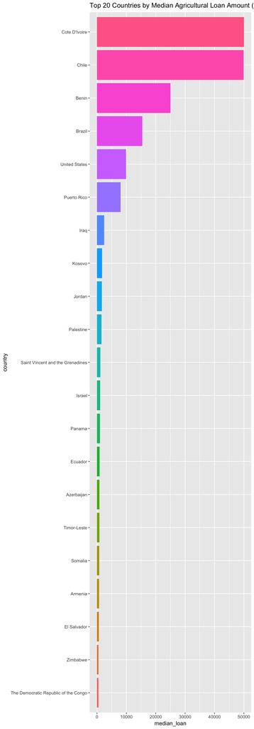

```r
library(ggplot2)
ag_df$country <- factor(ag_df$country, levels = ag_df$country[order(ag_df$median_loan)])

ggplot(ag_df, aes(x=country, group = country, y= median_loan))+
  theme(legend.position="none")+
  geom_bar(aes(fill = country), position = "dodge", stat="identity")+
  coord_flip()+
  labs(title="Top 20 Countries by Median Agricultural Loan Amount (USD)")
```

## References

Because I am using this as both a project and a learning exercise, I’m including the best results from my inevitable google searches here.

- http://bconnelly.net/2013/10/summarizing-data-in-python-with-pandas/
- https://rstudio.github.io/reticulate/articles/r_markdown.html#calling-r-from-python
- https://chrisalbon.com/python/data_wrangling/pandas_selecting_rows_on_conditions/